# Description:

- modeling of time for a DNA molecule to reach equilibrium in a CsCl gradient

## Notes:

**general**

- 1 Svedberg (S) unit = 10^-13
  - rate of sedimentation

**parameters**

- density-gradient proportionality constant (Beta^o or B) = 1.14e9 /beta
- average particle density in the gradient (D)
  - AKA, the buoyant density (g/cm^3) of particle in the salt (Pp)
- cfg_rpm (R)
- position of particle at equilibrium (P)
- dna_length in bp (L)
- sedimentation rate (S)
- time in hours (T)

**equations**

$S = 2.8 + 0.00834 * (L*666)^{0.479}$

$T = 1.13e14 * \beta^o * (D-1) / (R^4 * P^2 * S)$

## notes from Dan's N-SIP paper

- random 5kb reads from any genome could vary by ~13%
  - this translates to ~0.0127 g/ml

```python
%load_ext rmagic
```

```python
%%R
require(ggplot2)
require(gridExtra)
```

## Plotting buoyant density as a function of GC

### Equations:

$\rho = 1.660 + 0.098 * GC$

$GC = (\rho - 1.66) / 0.098$

**Where:**

$GC = fraction\ of\ GC\ (GC content)$

$\rho = buoyant\ density$

- calculations derived from emperical data in: http://www.sciencedirect.com/science/article/pii/S0022283662801004
- another resource: 'http://www.ncbi.nlm.nih.gov/pmc/articles/PMC222685/pdf/pnas00194-0137.pdf'

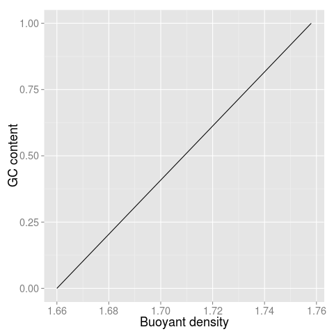

```python
%%R
# GC range
GC = seq(0,1,0.1)

## GC_fraction = (p - 1.66) / 0.098
GC2buoyant.density = function(x){ (x * 0.098) + 1.66 }

BD = GC2buoyant.density(GC)

tbl = as.data.frame(cbind(GC,BD))

p = ggplot(tbl, aes(BD, GC)) +
        #geom_point(size=3) +
        geom_line() +
        labs(x='Buoyant density', y='GC content') +
        #coord_flip() +
        theme( text = element_text(size=18) )
print(p)
```

### Plotting density-gradient proportionality constant (Beta^o) for CsCl as a function of density (25oC, g/cm)

- from Ludlum and Warner (1965)

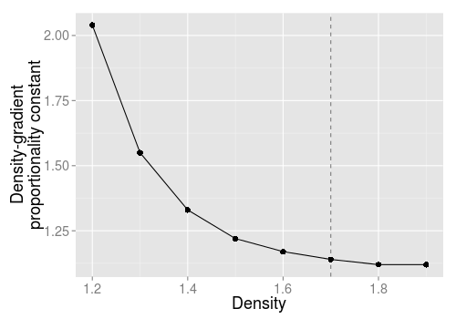

```python
%%R -w 500 -h 350

density = seq(1.2,1.9,0.1)
B.o = c(2.04,1.55,1.33,1.22,1.17,1.14,1.12,1.12)

tbl = as.data.frame(cbind(density, B.o))
#colnames(tbl) = c('Density', 'Density-gradient proportionality constant')

p = ggplot(tbl, aes(density, B.o)) +
        geom_point(size=3) +
        geom_line() +
        labs(x='Density', y='Density-gradient\nproportionality constant') +
        theme( text = element_text(size=18)) +
        geom_vline(xintercept=1.7, linetype='dashed', alpha=0.5)
print(p)
```

### Plotting dna fragment size as a function of time to equilibrium

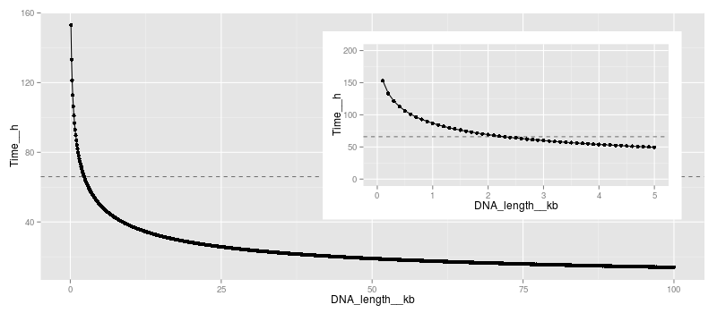

```python
%%R -w 800 -h 350

# rpm
R = 55000

# average particle density (DOE grant)
D = 1.70

# Beta^o
B = 1.14e9

# radius of the isoconcentration point from cfg center (AKA: r.p)
## position of the particle at equilibrium
P = 3.78     # TLA110 rotor

# dna in bp from 0.1kb - 100kb
L = seq(100, 100000, 100)

# calculating S
S = 2.8 + (0.00834 * (L*666)^0.479)

# calculating T
T = 1.13e14 * B * (D-1) / (R^4 * P^2 * S)

# plotting
tbl = as.data.frame(cbind(L/1000, T))
colnames(tbl) = c('DNA_length__kb', 'Time__h')

p = ggplot(tbl, aes(DNA_length__kb, Time__h)) +
        geom_point() +
        geom_line() +
        geom_hline(yintercept=66, linetype='dashed', alpha=0.5)  # DOE grant time



# plotting at sm
p.sub = ggplot(tbl, aes(DNA_length__kb, Time__h)) +
        geom_point() +
        geom_line() +
        scale_x_continuous(limits=c(0,5)) +
        scale_y_continuous(limits=c(0,200)) +
        geom_hline(yintercept=66, linetype='dashed', alpha=0.5)

vp = viewport(width=0.50, height=0.60, x = 0.70, y = 0.6)

print(p)
print(p.sub, vp=vp)
```

## Assessing time to equilibrium across GC range

**radius positions for density gradient spanning 1.660 - 1.760**

- using Dan's 'Centrifugal calcs.xls' file
  - 'Position at a given density'
  - assuming gradient average density of 1.7
- radius for density of 1.660: 3.4 (cm)
- radius for density of 1.760: 4.29 (cm)

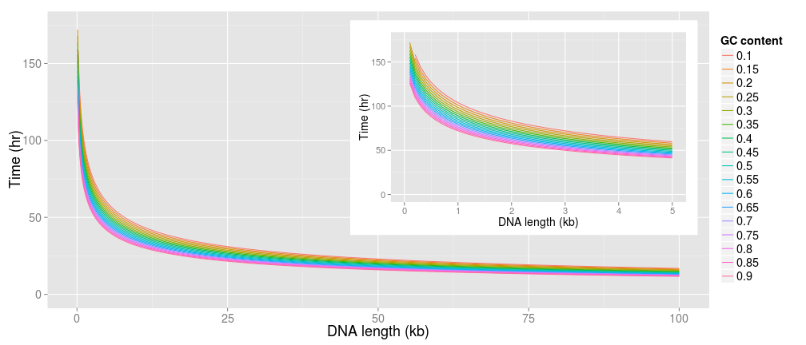

```python
%%R -w 14 -h 6 -u in
require(ggplot2)
require(reshape)

# radius top,bottom
r.top = 2.6
r.bottom = 4.85

# isoconcentration point
I = sqrt((r.top^2 + r.top * r.bottom + r.bottom^2)/3)

# rpm
R = 55000

# particle density
D = 1.70

# beta^o
B = 1.14e9

# dna in bp from 0.1kb - 100kb
L = seq(100, 100000, 100)

# angular velocity
w = ((2 * 3.14159 * R)/60)^2

# DNA GC content
G.C = seq(0.1, 0.9, 0.05)

# Molecular weight
# M.W in relation to GC content (dsDNA)
A = 313.2
T = 304.2
C = 289.2
G = 329.2
GC = G + C
AT = A + T
#GC2MW = function(x){ x*GC + (1-x)*AT + 157 }  # assuming 5' monophosphate on end of molecules
GC2MW = function(x){ x*GC + (1-x)*AT  }
M.W = sapply(G.C, GC2MW)

# buoyant density
## GC_fraction = (p - 1.66) / 0.098
GC2buoyant.density = function(x){ (x * 0.098) + 1.66 }
B.D = GC2buoyant.density(G.C)

# radius of the isoconcentration point from cfg center (AKA: r.p)
## position of the particle at equilibrium
buoyant.density2radius = function(x){ sqrt( ((x-D)*2*B/w) + I^2 ) }
P = buoyant.density2radius(B.D)

# calculating S
S.fun = function(L){ 2.8 + (0.00834 * (L*M.W)^0.479) }
S = t(sapply( L, S.fun ))

# calculating T
T = matrix(ncol=17, nrow=length(L))
for(i in 1:ncol(S)){
    T[,i] = 1.13e14 * B * (D-1) / (R^4 * P[i]^2 * S[,i])
}

## formating
T = as.data.frame(T)
colnames(T) = G.C
T$dna_size__kb = L / 1000
T.m = melt(T, id.vars=c('dna_size__kb'))
colnames(T.m) = c('dna_size__kb', 'GC_content', 'time__h')
#T.m$GC_content = as.numeric(as.character(T.m$GC_content))

## plotting
p = ggplot(T.m, aes(dna_size__kb, time__h, color=GC_content, group=GC_content)) +
        geom_line() +
        scale_y_continuous(limits=c(0,175)) +
        labs(x='DNA length (kb)', y='Time (hr)') +
        scale_color_discrete(name='GC content') +
        #geom_hline(yintercept=66, linetype='dashed', alpha=0.5) +
        theme( text = element_text(size=18) )

#print(p)

# plotting at small scale
p.sub = ggplot(T.m, aes(dna_size__kb, time__h, color=GC_content, group=GC_content)) +
        geom_line() +
        scale_x_continuous(limits=c(0,5)) +
        scale_y_continuous(limits=c(0,175)) +
        labs(x='DNA length (kb)', y='Time (hr)') +
        scale_color_discrete(name='GC content') +
        #geom_hline(yintercept=66, linetype='dashed', alpha=0.5) +
        theme(
            text = element_text(size=14),
            legend.position = 'none'
            )

vp = viewport(width=0.43, height=0.62, x = 0.65, y = 0.63)
print(p)
print(p.sub, vp=vp)

pdf("~/notebook/deltaGC_notes/data/CsCl_calc/140409_time2Eq.pdf", width=14, height=6)
print(p)
print(p.sub, vp=vp)
dev.off()
x = 1
```